# Exercise 12

Jennie

2024-04-15

# Exercise 12

## **Learning Objectives**

- Run exploratory multivariate regression to evaluate different models

#### **Preliminaries**

- Set up a new *GitHub* repo in your *GitHub* workspace named “exercise-12” and clone that down to your computer as a new *RStudio* project. The instructions outlined as **Method 1** in [**Module 6**](https://difiore.github.io/ada-2024/06-module.html) will be helpful.

Using the {tidyverse} `read_tsv()` function, load the “Mammal_lifehistories_v2.txt” dataset from [this URL](https://raw.githubusercontent.com/difiore/ada-2024-datasets/main/Mammal_lifehistories_v2.txt) as a “tibble” named **d**. As discussed in class, this is dataset that compiles life history and other variables for over 1400 species of placental mammals from 17 different Orders. **Data source**: Ernest SKM. (2003). Life history characteristics of placental nonvolant mammals. *Ecology* 84: 3402–3402.

```r
# load dataset from URL
library(tidyverse)
```

```r
f <- "https://raw.githubusercontent.com/difiore/ada-2024-datasets/main/Mammal_lifehistories_v2.txt"
d <- read_tsv(f, col_names = TRUE)
```

- Do a bit of exploratory data analysis with this dataset, e.g., using the {skimr} package. Which of the variables are categorical and which are numeric?

The categorical variables are **order**, **family**, **Genus**, and **species**. The numeric variables are **mass(g)**, **gestation(mo)**, **newborn(g)**, **weaning(mo)**, **wean mass(g)**, **AFR(mo)**, **max. life(mo)**, **litter size**, **litters/year**, and **refs**.

```r
# view a summary of the columns (types, min, max, mean, etc.)
library(skimr)
skim(d)
```

Data summary

| Name | d |
| --- | --- |
| Number of rows | 1440 |
| Number of columns | 14 |
| _______________________ |  |
| Column type frequency: |  |
| character | 4 |
| numeric | 10 |
| ________________________ |  |
| Group variables | None |

**Variable type: character**

| skim_variable | n_missing | complete_rate | min | max | empty | n_unique | whitespace |
| --- | --- | --- | --- | --- | --- | --- | --- |
| order | 0 | 1 | 7 | 14 | 0 | 17 | 0 |
| family | 0 | 1 | 6 | 15 | 0 | 96 | 0 |
| Genus | 0 | 1 | 3 | 16 | 0 | 618 | 0 |
| species | 0 | 1 | 3 | 17 | 0 | 1191 | 0 |

**Variable type: numeric**

| skim_variable | n_missing | complete_rate | mean | sd | p0 | p25 | p50 | p75 | p100 | hist |
| --- | --- | --- | --- | --- | --- | --- | --- | --- | --- | --- |
| mass(g) | 0 | 1 | 3.835767e+05 | 5.055163e+06 | -999 | 50 | 403.02 | 7009.17 | 1.490000e+08 | ▇▁▁▁▁ |
| gestation(mo) | 0 | 1 | -2.872500e+02 | 4.553600e+02 | -999 | -999 | 1.05 | 4.50 | 2.146000e+01 | ▃▁▁▁▇ |
| newborn(g) | 0 | 1 | 6.703150e+03 | 9.091252e+04 | -999 | -999 | 2.65 | 98.00 | 2.250000e+06 | ▇▁▁▁▁ |
| weaning(mo) | 0 | 1 | -4.271700e+02 | 4.967100e+02 | -999 | -999 | 0.73 | 2.00 | 4.800000e+01 | ▆▁▁▁▇ |
| wean mass(g) | 0 | 1 | 1.604893e+04 | 5.036502e+05 | -999 | -999 | -999.00 | 10.00 | 1.907500e+07 | ▇▁▁▁▁ |
| AFR(mo) | 0 | 1 | -4.081200e+02 | 5.049700e+02 | -999 | -999 | 2.50 | 15.61 | 2.100000e+02 | ▆▁▁▁▇ |
| max. life(mo) | 0 | 1 | -4.902600e+02 | 6.153000e+02 | -999 | -999 | -999.00 | 147.25 | 1.368000e+03 | ▇▁▅▁▁ |
| litter size | 0 | 1 | -5.563000e+01 | 2.348800e+02 | -999 | 1 | 2.27 | 3.84 | 1.418000e+01 | ▁▁▁▁▇ |
| litters/year | 0 | 1 | -4.771400e+02 | 5.000300e+02 | -999 | -999 | 0.38 | 1.15 | 7.500000e+00 | ▇▁▁▁▇ |
| refs | 0 | 1 | 1.054762e+12 | 3.619709e+13 | 1 | 116 | 1229.00 | 1242249.75 | 1.368101e+15 | ▇▁▁▁▁ |

## **Challenge**

#### **Step 1**

- Replace all values of -999 (the authors’ code for missing data) with `NA`.

> **HINT:** This is easy to do in base {R}, but you can also check out the `replace_with_na_all()` function from the {naniar} package.

```r
# this dataset uses "-999.0" to mean "NA"; make it say "NA" instead
library(naniar)
d_new <- replace_with_na_all(data = d, condition = ~.x == -999.0)
```

#### **Step 2**

- Drop the variables **litter size** and **refs**.

```r
# litter size = 12th column; refs = 14th column
d_new <- d_new[ -c(12, 14)]
```

#### **Step 3**

- Log transform **all** of the other numeric variables.

> **HINT:** There are lots of ways to do this… look into `mutate(across(where(), .funs))` for an efficient motif.

```r
# log transform the numeric variables
d_new <- d_new |>
  mutate(across(where(is.numeric), log))
# this gives warnings that NaNs were produced, but the log values appear to be okay.
```

#### **Step 4**

- Regress the (now log transformed) age [**gestation(mo)**, **weaning(mo)**, **AFR(mo)** (age at first reproduction), and **max. life(mo)** (maximum lifespan)] and mass [**newborn(g)** and **wean mass(g)**] variables on (now log transformed) overall body **mass(g)** and add the residuals to the dataframe as new variables (**relGest**, **relWean**, **relAFR**, **relLife**, **relNewbornMass**, and **relWeaningMass**).

> **HINT:** Use “na.action=na.exclude” in your`lm()` calls. With this argument set, the residuals will be padded to the correct length by inserting NAs for cases with missing data.

```r
# I first tried to run one of the models below, but it was giving an error that some of the values are NaN or Inf. Will replace those with NA:
d_new[is.na(d_new) | d_new=="Inf"] = NA
d_new[is.na(d_new) | d_new=="-Inf"] = NA
# And now residuals for the 6 listed variables:
relGest <- resid(lm(`gestation(mo)` ~ `mass(g)`, data = d_new, na.action = na.exclude))
relWean <- resid(lm(`weaning(mo)` ~ `mass(g)`, data = d_new, na.action = na.exclude))
relAFR <- resid(lm(`AFR(mo)` ~ `mass(g)`, data = d_new, na.action = na.exclude))
relLife <- resid(lm(`max. life(mo)` ~ `mass(g)`, data = d_new, na.action = na.exclude))
relNewbornMass <- resid(lm(`newborn(g)` ~ `mass(g)`, data = d_new, na.action = na.exclude))
relWeaningMass <- resid(lm(`wean mass(g)` ~ `mass(g)`, data = d_new, na.action = na.exclude))
# Add them to d_new:
d_new$relGest <- relGest
d_new$relWean <- relWean
d_new$relAFR <- relAFR
d_new$relLife <- relLife
d_new$relNewbornMass <- relNewbornMass
d_new$relWeaningMass <- relWeaningMass
```

#### **Step 5**

- Plot residuals of max lifespan (**relLife**) in relation to **Order**. Which mammalian orders have the highest residual lifespan?

- Plot residuals of newborn mass (**relNewbornMass**) in relation to **Order**. Which mammalian orders have the have highest residual newborn mass?

- Plot residuals of weaning mass (**relWeaningMass**) in relation to **Order**. Which mammalian orders have the have highest relative weaning mass?

Insectivora and Perissodactyl appear to have the highest **relWeaningMass**.

> **NOTE:** There will be lots of missing data for the latter two variables!

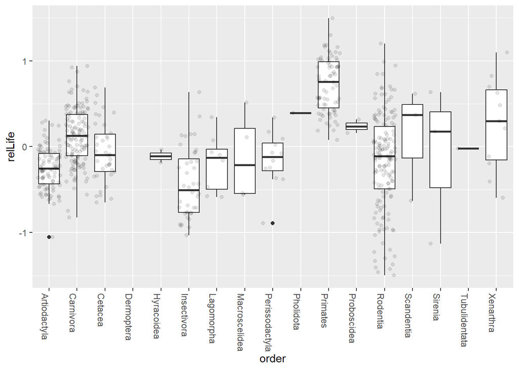

```r
library(ggplot2)
# relLife in relation to Order:
plot1 <- ggplot(data = d_new, aes(x = `order`, y = relLife)) + geom_boxplot() + geom_jitter(alpha = 0.1) + theme(axis.text.x=element_text(angle = -90, hjust = 0))
print(plot1)
```

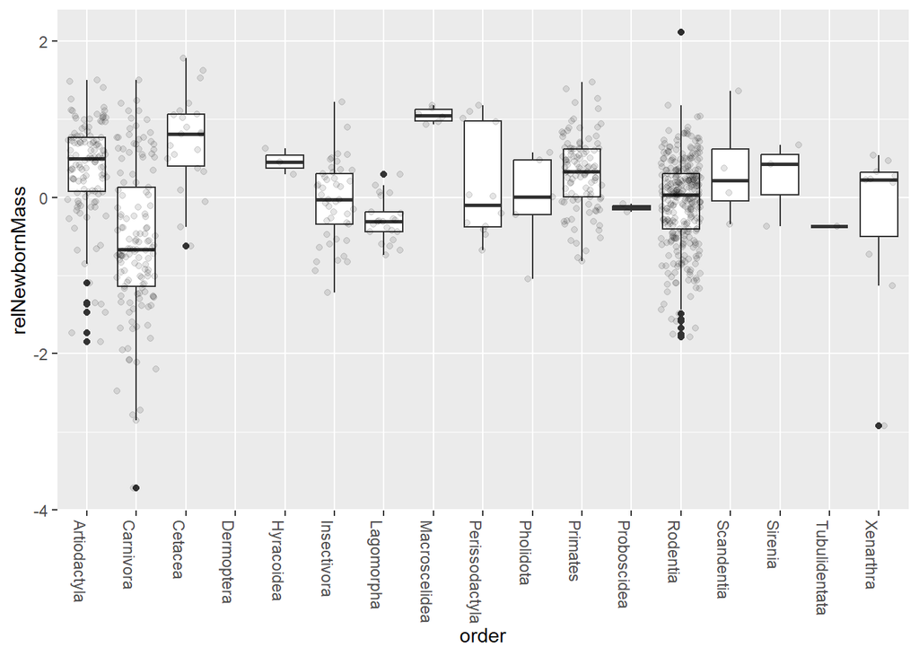

```r
# relNewbornMass in relation to Order:
plot2 <- ggplot(data = d_new, aes(x = `order`, y = relNewbornMass)) + geom_boxplot() + geom_jitter(alpha = 0.1) + theme(axis.text.x=element_text(angle = -90, hjust = 0))
print(plot2)
```

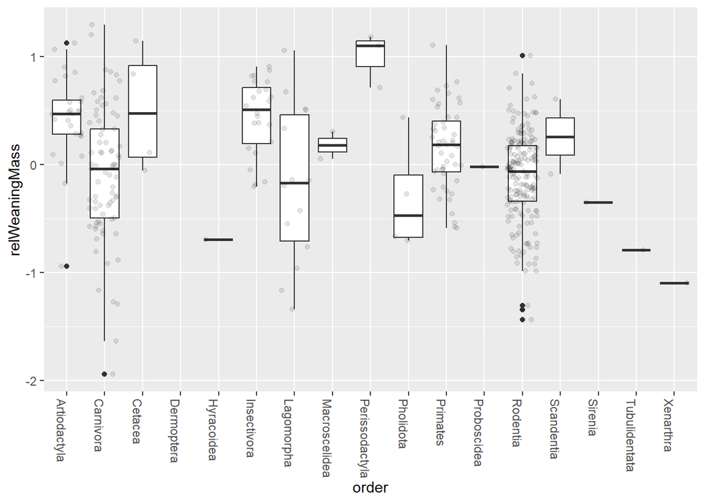

```r
# relWeaningMass in relation to Order:
plot3 <- ggplot(data = d_new, aes(x = `order`, y = relWeaningMass)) + geom_boxplot() + geom_jitter(alpha = 0.1) + theme(axis.text.x=element_text(angle = -90, hjust = 0))
print(plot3)
```

#### **Step 6**

- Run models and a model selection process to evaluate what (now log transformed) variables best predict each of the two response variables, **max. life(mo)** and **AFR(mo)**, from the set of the following predictors: **gestation(mo)**, **newborn(g)**, **weaning(mo)**, **wean mass(g)**, **litters/year**, and overall body **mass(g)**.

> **HINT:** Before running models, winnow your dataset to drop rows that are missing the respective response variable or any of the predictors, e.g., by using `drop_na()`.
- For each of the two response variables, indicate what is the best model overall based on AICc and how many models have a delta AICc of 4 or less.

- What variables, if any, appear in all of this set of “top” models?

- Calculate and plot the model-averaged coefficients and their CIs across this set of top models.

```r
# drop rows with missing data:
d_new <- d_new |> drop_na(`max. life(mo)`, `AFR(mo)`, `gestation(mo)`, `newborn(g)`, `weaning(mo)`, `wean mass(g)`, `litters/year`, `mass(g)`)
# Model for max. life(mo):
m_Life <- lm(data = d_new, `max. life(mo)` ~ `gestation(mo)` + `newborn(g)` + `weaning(mo)` + `wean mass(g)` + `litters/year` + `mass(g)`, na.action = "na.fail")
# model selection:
library(MuMIn)
mods_Life <- dredge(m_Life, beta = "none")
```

```
## Fixed term is "(Intercept)"
```

```r
mods.avg_Life <- summary(model.avg(mods_Life, subset = delta < 4, fit = TRUE))
print(mods.avg_Life)
```

```
##
## Call:
## model.avg(object = get.models(object = mods_Life, subset = delta <
##     4))
##
## Component model call:
## lm(formula = `max. life(mo)` ~ <5 unique rhs>, data = d_new, na.action
##      = na.fail)
##
## Component models:
##        df  logLik   AICc delta weight
## 1236    6 -122.21 256.83  0.00   0.42
## 12346   7 -121.65 257.86  1.03   0.25
## 12356   7 -122.19 258.95  2.11   0.14
## 1256    6 -123.63 259.69  2.85   0.10
## 123456  8 -121.59 259.91  3.07   0.09
##
## Term codes:
## `gestation(mo)`  `litters/year`       `mass(g)`    `newborn(g)`  `wean mass(g)`
##               1               2               3               4               5
##   `weaning(mo)`
##               6
##
## Model-averaged coefficients:
## (full average)
##                 Estimate Std. Error Adjusted SE z value Pr(>|z|)
## (Intercept)      4.00291    0.16134     0.16215  24.687  < 2e-16 ***
## `gestation(mo)`  0.31844    0.08975     0.09022   3.530 0.000416 ***
## `litters/year`  -0.24853    0.07848     0.07895   3.148 0.001645 **
## `mass(g)`        0.08746    0.04908     0.04925   1.776 0.075726 .
## `weaning(mo)`    0.13659    0.05294     0.05326   2.565 0.010332 *
## `newborn(g)`    -0.01920    0.04131     0.04146   0.463 0.643204
## `wean mass(g)`   0.00911    0.04176     0.04191   0.217 0.827903
##
## (conditional average)
##                 Estimate Std. Error Adjusted SE z value Pr(>|z|)
## (Intercept)      4.00291    0.16134     0.16215  24.687  < 2e-16 ***
## `gestation(mo)`  0.31844    0.08975     0.09022   3.530 0.000416 ***
## `litters/year`  -0.24853    0.07848     0.07895   3.148 0.001645 **
## `mass(g)`        0.09717    0.04164     0.04185   2.322 0.020236 *
## `weaning(mo)`    0.13659    0.05294     0.05326   2.565 0.010332 *
## `newborn(g)`    -0.05666    0.05398     0.05431   1.043 0.296810
## `wean mass(g)`   0.02724    0.06870     0.06898   0.395 0.692865
## ---
## Signif. codes:  0 '***' 0.001 '**' 0.01 '*' 0.05 '.' 0.1 ' ' 1
```

```r
confint_Life <- confint(mods.avg_Life)
print(confint_Life)
```

```
##                       2.5 %      97.5 %
## (Intercept)      3.68511191  4.32071260
## `gestation(mo)`  0.14160671  0.49526367
## `litters/year`  -0.40327078 -0.09378398
## `mass(g)`        0.01514783  0.17918817
## `weaning(mo)`    0.03219892  0.24097775
## `newborn(g)`    -0.16309576  0.04978052
## `wean mass(g)`  -0.10794856  0.16243631
```

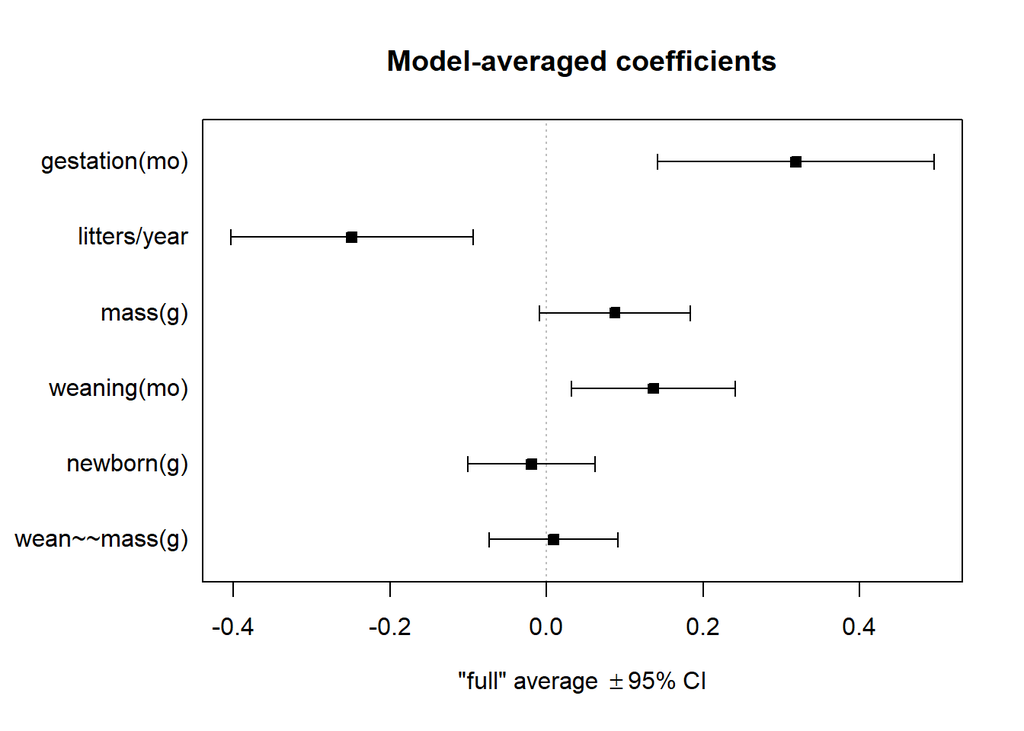

```r
plot4 <- plot(mods.avg_Life, full = TRUE, intercept = FALSE)
```

```r
print(plot4)
```

```
##                          px py          lx0 ly0         lx1 ly1
## `gestation(mo)`  0.31843519  6  0.141606708   6  0.49526367   6
## `litters/year`  -0.24852738  5 -0.403270783   5 -0.09378398   5
## `mass(g)`        0.08746290  4 -0.009057336   4  0.18398314   4
## `weaning(mo)`    0.13658833  3  0.032198921   3  0.24097775   3
## `newborn(g)`    -0.01920547  2 -0.100466619   2  0.06205567   2
## `wean mass(g)`   0.00911026  1 -0.073026096   1  0.09124662   1
```

```r
# Model for AFR(mo):
m_AFR <- lm(data = d_new, `AFR(mo)` ~ `gestation(mo)` + `newborn(g)` + `weaning(mo)` + `wean mass(g)` + `litters/year` + `mass(g)`, na.action = "na.fail")
# model selection:
mods_AFR <- dredge(m_AFR, beta = "none")
```

```
## Fixed term is "(Intercept)"
```

```r
mods.avg_AFR <- summary(model.avg(mods_AFR, subset = delta < 4, fit = TRUE))
print(mods.avg_AFR)
```

```
##
## Call:
## model.avg(object = get.models(object = mods_AFR, subset = delta <
##     4))
##
## Component model call:
## lm(formula = `AFR(mo)` ~ <10 unique rhs>, data = d_new, na.action =
##      na.fail)
##
## Component models:
##       df  logLik   AICc delta weight
## 1236   6 -154.40 321.23  0.00   0.20
## 1256   6 -154.55 321.52  0.30   0.18
## 126    5 -155.76 321.82  0.59   0.15
## 1246   6 -154.70 321.82  0.59   0.15
## 12356  7 -154.40 323.37  2.14   0.07
## 12346  7 -154.40 323.37  2.14   0.07
## 12456  7 -154.54 323.65  2.43   0.06
## 12     4 -157.96 324.12  2.89   0.05
## 123    5 -157.26 324.81  3.58   0.03
## 125    5 -157.32 324.94  3.71   0.03
##
## Term codes:
## `gestation(mo)`  `litters/year`       `mass(g)`    `newborn(g)`  `wean mass(g)`
##               1               2               3               4               5
##   `weaning(mo)`
##               6
##
## Model-averaged coefficients:
## (full average)
##                  Estimate Std. Error Adjusted SE z value Pr(>|z|)
## (Intercept)      2.059308   0.164411    0.165109  12.472  < 2e-16 ***
## `gestation(mo)`  0.424816   0.104323    0.104789   4.054 5.04e-05 ***
## `litters/year`  -0.736632   0.096521    0.097003   7.594  < 2e-16 ***
## `mass(g)`        0.013294   0.029383    0.029501   0.451    0.652
## `weaning(mo)`    0.125434   0.073485    0.073759   1.701    0.089 .
## `wean mass(g)`   0.009906   0.031169    0.031308   0.316    0.752
## `newborn(g)`     0.006295   0.028974    0.029108   0.216    0.829
##
## (conditional average)
##                 Estimate Std. Error Adjusted SE z value Pr(>|z|)
## (Intercept)      2.05931    0.16441     0.16511  12.472  < 2e-16 ***
## `gestation(mo)`  0.42482    0.10432     0.10479   4.054 5.04e-05 ***
## `litters/year`  -0.73663    0.09652     0.09700   7.594  < 2e-16 ***
## `mass(g)`        0.03511    0.03891     0.03915   0.897   0.3698
## `weaning(mo)`    0.14159    0.06171     0.06207   2.281   0.0225 *
## `wean mass(g)`   0.02921    0.04797     0.04823   0.606   0.5448
## `newborn(g)`     0.02227    0.05113     0.05140   0.433   0.6648
## ---
## Signif. codes:  0 '***' 0.001 '**' 0.01 '*' 0.05 '.' 0.1 ' ' 1
```

```r
confint_AFR <- confint(mods.avg_AFR)
print(confint_AFR)
```

```
##                       2.5 %     97.5 %
## (Intercept)      1.73570076  2.3829161
## `gestation(mo)`  0.21943208  0.6301994
## `litters/year`  -0.92675475 -0.5465098
## `mass(g)`       -0.04161694  0.1118418
## `weaning(mo)`    0.01992847  0.2632574
## `wean mass(g)`  -0.06532930  0.1237398
## `newborn(g)`    -0.07846591  0.1230037
```

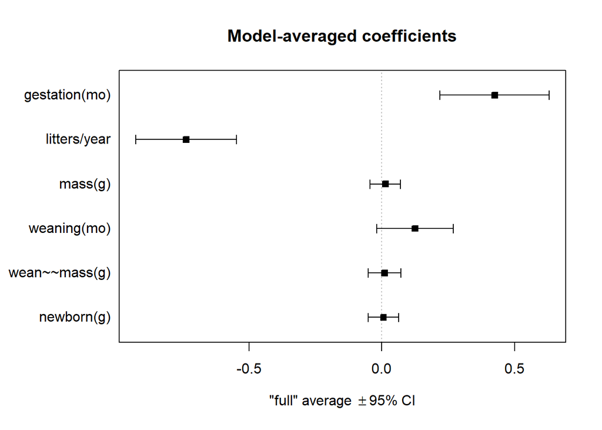

```r
plot5 <- plot(mods.avg_AFR, full = TRUE, intercept = FALSE)
```

```r
print(plot5)
```

```
##                           px py         lx0 ly0         lx1 ly1
## `gestation(mo)`  0.424815719  6  0.21943208   6  0.63019936   6
## `litters/year`  -0.736632281  5 -0.92675475   5 -0.54650981   5
## `mass(g)`        0.013293763  4 -0.04452686   4  0.07111438   4
## `weaning(mo)`    0.125434007  3 -0.01913137   3  0.26999938   3
## `wean mass(g)`   0.009905543  2 -0.05145792   2  0.07126901   2
## `newborn(g)`     0.006295123  1 -0.05075616   1  0.06334641   1
```